# COM747 Week 1 Seminar: Solutions and Discussion Guide

Exercise sheet sections 1–10, with the R refresher fully worked

> **How to use this notebook.** Sections 1–7 of the sheet are discussion tasks: you’ll find short model answers and prompts to take further. Section 8 is the R refresher: every line is run, with a prediction (“estimate the output before running”) and an explanation of what happened. Try predicting before you read the output. Lines in the sheet that fail when copied (curly quotes from Word) are flagged in orange.

# 1. The assignment

- Read the assignment brief and bring questions to the lab.
- Put the submission deadlines **and the class test date** (Week 8, on campus, R only) in your diary now.

# 2. Definitions: how the terms relate

| Term | A working definition | Relationship |
| --- | --- | --- |
| **Statistics** | The science of collecting, summarising and drawing conclusions from data under uncertainty | The mathematical foundation for everything below |
| **Data science** | An interdisciplinary field using statistics, computing and domain knowledge to extract knowledge and value from data | The umbrella; includes analytics, ML, engineering, communication |
| **Data analytics** | Examining data to answer specific questions and support decisions (descriptive → diagnostic → predictive → prescriptive) | A practical, question-driven part of data science |
| **Data mining** | Discovering patterns in large datasets (clusters, rules, anomalies) | One step of knowledge discovery; uses ML and statistics |
| **Knowledge discovery (KDD)** | The whole process: selection → preprocessing → transformation → data mining → interpretation | The lifecycle that contains data mining |
| **Machine learning** | Algorithms that improve at a task by learning from data rather than being explicitly programmed | A toolkit used by data mining and AI |
| **Algorithm** | A finite, well-defined sequence of steps that solves a problem | k-means, apriori and gradient descent are all algorithms |
| **Artificial intelligence** | Systems that perform tasks we associate with human intelligence | Includes ML, but also rule-based systems (Week 11) |

**Discuss:** Is a linear regression “statistics” or “machine learning”? (Both: statisticians emphasise inference about coefficients; ML emphasises prediction on new data.) Try Google Trends for “data science” vs “machine learning” vs “generative AI”: which has grown fastest since 2022?

# 3. How much data, and what’s trending?

Estimates put the world’s data creation at a few hundred million terabytes per day, growing every year. Rather than memorising a figure that dates quickly, discuss *where* it comes from (video, sensors and IoT, transactions, social media, machine logs) and what that means: storage costs, privacy, and the need for automated analysis. Trends worth searching: generative AI and LLMs, MLOps, data quality and data-centric AI, responsible/explainable AI, edge computing.

# 4. Data science lifecycles

**CRISP-DM** has six phases, with arrows back as you learn: *business understanding → data understanding → data preparation → modelling → evaluation → deployment*. Martínez-Plumed et al. (2019) argue modern projects are *trajectories*: they skip, repeat or add steps (e.g. data acquisition, data simulation, narrative exploration) rather than following one fixed loop.

| Lifecycle | Distinctive feature |
| --- | --- |
| KDD | Academic; focuses on the data-to-knowledge pipeline |
| SEMMA (SAS) | Sample, Explore, Modify, Model, Assess: tool-centred, starts after the business question |
| CRISP-DM | Starts and ends with the business; most widely used |
| ASUM-DM (IBM) | Adds project management and agile iterations to CRISP-DM |
| TDSP (Microsoft) | Team roles, templates, version control, deployment and acceptance |

**Discuss:** Which phase usually takes the most time? (Data preparation: often quoted as 60–80% of a project.)

# 5. Data quality

- **Data quality**: fitness for purpose. Common dimensions: *accuracy, completeness, consistency, timeliness, validity, uniqueness*. Check with summaries, missing-value counts, ranges, duplicates and cross-checks against the source (Week 10’s validation).
- **Data cleaning/cleansing**: fixing or removing errors: missing values, impossible values, duplicates, inconsistent labels (“Male”, “M”, “male”).
- **Downstream tasks**: every step that uses the output of an earlier step (modelling, reporting, decisions).
- **Example of harm downstream**: missing ages coded as 0 → the mean age is too low → a model learns that “age 0” predicts something → wrong decisions. Or a duplicate-rows bug that leaks test data into training and inflates accuracy.
- **Cleaning vs wrangling**: cleaning fixes *errors*; wrangling (munging) *reshapes* correct data into the form an analysis needs (joining, pivoting, aggregating, creating features).

# 6. Reading

Lantz, *Machine Learning with R* (4th ed., 2023) is the module text; Géron’s *Hands-On Machine Learning* is the Python equivalent. Both are on O’Reilly Learning via the library. The class test uses R only.

# 7. R vs Python

|  | R | Python |
| --- | --- | --- |
| Designed for | Statistics and data analysis | General-purpose programming |
| Strengths | Statistical tests and models built in; CRAN packages; ggplot2; R Markdown; Shiny | Deep learning (PyTorch, TensorFlow); software engineering; production systems |
| Typical tools | RStudio, R Markdown / Quarto | Jupyter, VS Code, Google Colab |
| Data frames | Built in (`data.frame`), tidyverse, data.table | pandas, polars |

Many data scientists use both. Learning R well first makes Python easier, and vice versa.

# 8. R refresher, fully worked

## 8.1 RStudio orientation

- **Console** (bottom left): type and run commands immediately.
- **Environment / History** (top right): objects you’ve created; commands you’ve run.
- **Files / Plots / Packages / Help / Viewer** (bottom right).
- **Script / data viewer** (top left): write and save code; `View(df)` opens data here.

Create a script with *File → New File → R Script* and save it (*Ctrl/Cmd + S*). Run a line with *Ctrl/Cmd + Enter*.

## 8.2 The working directory

```r
getwd()                          # shows the working directory: where R reads and writes files
setwd("C:/myfolder/data")        # change it (use forward slashes, even on Windows)
```

**Copy-paste trap.** The sheet shows `setwd(“C:/myfolder/data")` with a curly opening quote. R only accepts straight quotes `"` or `'`, so this gives *Error: unexpected input*. Retype the quotes. In RStudio you can also use *Session → Set Working Directory → Choose Directory*, or better, an RStudio Project.

## 8.3 Vectors and summaries

```r
x <- c(3, 5, 10, 4)     # c() combines values into a vector
length(x)               # 4 elements
```

```
## [1] 4
```

```r
mean(x)                 # (3 + 5 + 10 + 4) / 4 = 5.5
```

```
## [1] 5.5
```

```r
sd(x)                   # sample standard deviation (divides by n - 1)
```

```
## [1] 3.109126
```

```r
summary(x)              # min, quartiles, median, mean, max
```

```
##    Min. 1st Qu.  Median    Mean 3rd Qu.    Max.
##    3.00    3.75    4.50    5.50    6.25   10.00
```

```r
sqrt(x)                 # applied to every element: R is vectorised
```

```
## [1] 1.732051 2.236068 3.162278 2.000000
```

## 8.4 Evaluation functions

*Predict first*: x is 3, 5, 10, 4.

```r
any(x > 8)      # predict: TRUE  (10 > 8)
```

```
## [1] TRUE
```

```r
any(x < 8)      # predict: TRUE  (3, 5 and 4)
```

```
## [1] TRUE
```

```r
all(x > 50)     # predict: FALSE (none are)
```

```
## [1] FALSE
```

```r
which(x > 4)    # predict: 2 3   (positions, not values: 5 is at position 2, 10 at 3)
```

```
## [1] 2 3
```

## 8.5 Subsetting

```r
y <- x[x > 4]               # predict: 5 10        keep values where the condition is TRUE
y
```

```
## [1]  5 10
```

```r
x > 4                       # the logical vector used inside [ ]
```

```
## [1] FALSE  TRUE  TRUE FALSE
```

```r
y <- x[x > 5 | x == 3]      # predict: 3 10        | means OR
y
```

```
## [1]  3 10
```

```r
x[x > 4 & x < 10]           # & means AND: 5
```

```
## [1] 5
```

## 8.6 Recoding

```r
x[x > 4] <- 0               # predict: 3 0 0 4     replace values that meet a condition
x
```

```
## [1] 3 0 0 4
```

## 8.7 Vector arithmetic and recycling

```r
2 + c(6, 0, 9, 20, 22)      # 8 2 11 22 24: 2 is added to each element
```

```
## [1]  8  2 11 22 24
```

```r
3 * c(6, 0, 9, 20, 22)      # 18 0 27 60 66
```

```
## [1] 18  0 27 60 66
```

```r
x <- c(3, 4, 2)
x + 2                       # R recycles 2 into c(2, 2, 2): 5 6 4
```

```
## [1] 5 6 4
```

```r
c(1, 2, 4) + c(6, 0, 9, 20, 22, 11)   # the short vector is recycled: c(1,2,4,1,2,4) + ...
```

```
## [1]  7  2 13 21 24 15
```

When the longer length isn’t a multiple of the shorter, R still recycles but warns you, because it’s usually a bug:

```r
c(1, 2) + c(10, 20, 30)     # warning: longer object length is not a multiple of shorter object length
```

```
## Warning in c(1, 2) + c(10, 20, 30): longer object length is not a multiple of
## shorter object length
```

```
## [1] 11 22 31
```

## 8.8 Rounding

```r
x <- c(9.5, 16.3, 25.1)
round(x)                    # 10 16 25 (9.5 goes to the even number 10)
```

```
## [1] 10 16 25
```

```r
round(c(0.5, 1.5, 2.5))     # 0 2 2: R rounds halves to the nearest EVEN number (IEC 60559)
```

```
## [1] 0 2 2
```

```r
round(3.14159, 2); signif(123456, 2); ceiling(2.1); floor(2.9)
```

```
## [1] 3.14
```

```
## [1] 120000
```

```
## [1] 3
```

```
## [1] 2
```

## 8.9 Key–value pairs (named vectors)

```r
x <- c(1, 2, 3)
names(x) <- c("a", "b", "c")   # give each element a name
x
```

```
## a b c
## 1 2 3
```

```r
x["b"]                         # 2, looked up by name rather than position
```

```
## b
## 2
```

The sheet’s `names(x) <- c(“a”, ”b”, “c”)` uses curly quotes, which fail in R. Use straight quotes as above.

## 8.10 Explicit coercion

```r
x <- c(0:6)
class(x)              # "integer": 0:6 makes whole numbers
```

```
## [1] "integer"
```

```r
as.numeric(x)         # 0 1 2 3 4 5 6 as doubles
```

```
## [1] 0 1 2 3 4 5 6
```

```r
as.logical(x)         # 0 is FALSE, any other number TRUE
```

```
## [1] FALSE  TRUE  TRUE  TRUE  TRUE  TRUE  TRUE
```

```r
as.character(x)       # "0" "1" ... text
```

```
## [1] "0" "1" "2" "3" "4" "5" "6"
```

```r
x <- as.character(x)
class(x)              # now "character"; mean(x) would no longer work
```

```
## [1] "character"
```

## 8.11 Nonsensical coercion

```r
x <- c("a", "b", "c")
as.numeric(x)         # NA NA NA, with a warning: "NAs introduced by coercion"
```

```
## [1] NA NA NA
```

```r
as.logical(x)         # NA NA NA (only "TRUE"/"true"/"T" and "FALSE"/"false"/"F" convert)
```

```
## [1] NA NA NA
```

```r
as.numeric(c("1", "2.5", "three"))   # a real-world case: one bad value becomes NA
```

```
## [1] 1.0 2.5  NA
```

## 8.12 Simulating data

```r
# ?rnorm explains: rnorm(n, mean = 0, sd = 1)
x <- rnorm(10)               # 10 values from a standard normal distribution
x <- rnorm(10, 20, 2)        # 10 values with mean 20, SD 2
summary(x)                   # the sample mean is close to, but not exactly, 20
```

```
##    Min. 1st Qu.  Median    Mean 3rd Qu.    Max.
##   15.53   18.58   20.77   20.08   21.63   22.98
```

## 8.13 Setting the seed

```r
set.seed(1)
rnorm(5)                     # five numbers
```

```
## [1] -0.6264538  0.1836433 -0.8356286  1.5952808  0.3295078
```

```r
rnorm(5)                     # five DIFFERENT numbers: the generator moved on
```

```
## [1] -0.8204684  0.4874291  0.7383247  0.5757814 -0.3053884
```

```r
set.seed(1)
rnorm(5)                     # the same as the first five: reproducible
```

```
## [1] -0.6264538  0.1836433 -0.8356286  1.5952808  0.3295078
```

## 8.14 Sampling and bootstrapping

```r
set.seed(1)
sample(c(1:10), 4)                     # 4 different numbers from 1 to 10 (without replacement)
```

```
## [1] 9 4 7 1
```

```r
sample(c(1:10), 10, replace = TRUE)    # 10 draws WITH replacement: repeats allowed
```

```
##  [1]  2  7  2  3  1  5  5 10  6 10
```

A bootstrap resamples the data with replacement many times to see how much a statistic varies:

```r
set.seed(1)
marks <- c(55, 62, 48, 71, 66, 59, 80, 45, 68, 73)
boot_means <- replicate(1000, mean(sample(marks, replace = TRUE)))
mean(marks)
```

```
## [1] 62.7
```

```r
quantile(boot_means, c(0.025, 0.975))  # a 95% bootstrap confidence interval for the mean
```

```
##    2.5%   97.5%
## 55.9975 69.5000
```

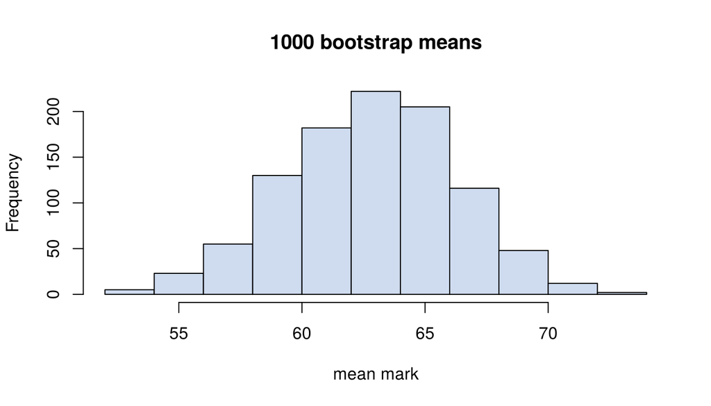

```r
hist(boot_means, col = "#cfdcf0", main = "1000 bootstrap means", xlab = "mean mark")
```

## 8.15 Matrices

```r
m <- matrix(c(1, 2, 3, 4, 5, 6), nrow = 2, ncol = 3)
m                         # filled column by column: first column is 1 2
```

```
##      [,1] [,2] [,3]
## [1,]    1    3    5
## [2,]    2    4    6
```

```r
dim(m); nrow(m); ncol(m)  # 2 3, 2, 3
```

```
## [1] 2 3
```

```
## [1] 2
```

```
## [1] 3
```

```r
colnames(m) <- c("a", "b", "c")
m[, "b"]                  # column b: 3 4
```

```
## [1] 3 4
```

```r
m[2, 2]                   # row 2, column 2: 4
```

[output not shown]

```r
m[, 2]                    # all of column 2: 3 4
```

```
## [1] 3 4
```

```r
m[1, ]                    # all of row 1: 1 3 5
```

```
## a b c
## 1 3 5
```

```r
m[, 1:2]                  # columns 1 and 2
```

```
##      a b
## [1,] 1 3
## [2,] 2 4
```

```r
matrix(1:6, nrow = 2, byrow = TRUE)   # byrow = TRUE fills row by row instead
```

```
##      [,1] [,2] [,3]
## [1,]    1    2    3
## [2,]    4    5    6
```

# 9–10. Going further

- W3Schools’ R tutorial (https://www.w3schools.com/r/) is a quick reference for syntax.
- Lantz chapter 2 (“Managing and Understanding Data”) covers vectors, factors, lists, data frames, matrices, and exploring data: the foundation for Weeks 2–3.

# Summary

| Idea | R |
| --- | --- |
| Create a vector | `c()`, `1:10`, `seq()`, `rep()` |
| Summaries | `length()`, `mean()`, `sd()`, `summary()` |
| Conditions | `any()`, `all()`, `which()` |
| Subset and recode | `x[x > 4]`, `x[x > 4] <- 0`, `&`, `\|` |
| Coercion | `class()`, `as.numeric()`, `as.character()`, `as.logical()` |
| Random numbers | `rnorm()`, `sample()`, `set.seed()` |
| Matrices | `matrix()`, `dim()`, `m[i, j]`, `colnames()` |